# Project

# Next we can look at how mass varies between species

Let’s first plot the data by using a boxplot.

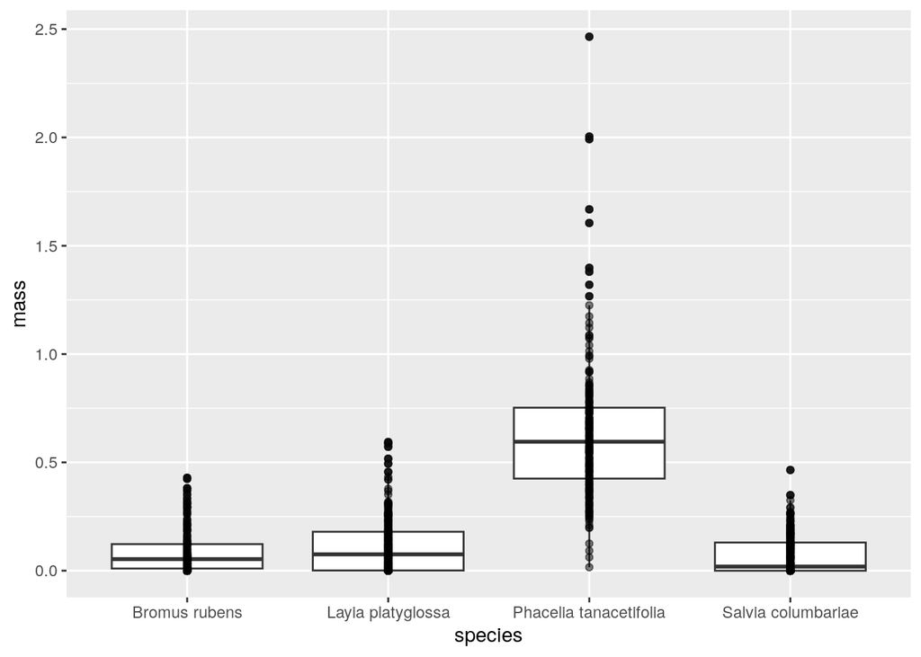

```r
ggplot(dry_mass, aes(species, mass))+
     geom_boxplot()+
     geom_point(alpha = 0.5)
```

There is a point that appears fairly distant from the mean in the Phacelia tanacetifolia plot, but there isn’t a clear outlier.

Now we can put the data into matrix form so that we can run a chisq.test

```r
mass.mat <- xtabs(mass ~ species, data = dry_mass)
mass.mat
```

```
## species
##          Bromus rubens      Layia platyglossa Phacelia tanacetifolia
##                 17.951                 24.001                132.581
##     Salvia columbariae
##                 15.058
```

Now we can run the test

```r
chisq.test(mass.mat)
```

```
##
##  Chi-squared test for given probabilities
##
## data:  mass.mat
## X-squared = 205, df = 3, p-value < 2.2e-16
```

Since we have a low p value, we can reject the null hypothesis and there is a clear relationship between the species and mass.

# Lets look at levels and mass

```r
low_med_data<-dry_mass %>% filter(factor == "Low" | factor == "Medium")

low_med_data$factor <- factor(low_med_data$factor)
```

Lets look at a figure of the data

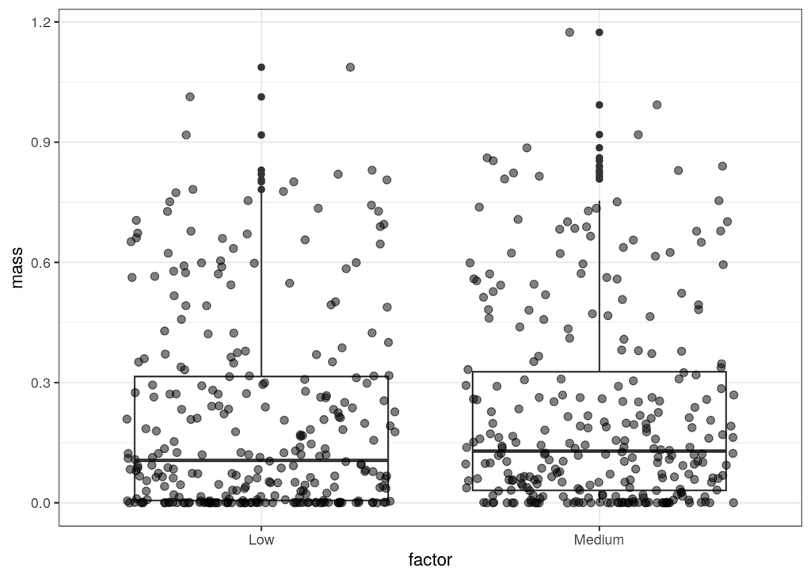

```r
ggplot(low_med_data, aes(factor, mass))+
     geom_boxplot()+
     geom_point(position = "jitter", size = 2, alpha = 0.5)+
     theme_bw()
```

The plots look similar, but lets do a formal test.

Now let’s do a t-test

```r
MyT<-t.test(mass ~ factor, data = low_med_data)
MyT
```

```
##
##  Welch Two Sample t-test
##
## data:  mass by factor
## t = -0.68879, df = 557.94, p-value = 0.4912
## alternative hypothesis: true difference in means between group Low and group Medium is not equal to 0
## 95 percent confidence interval:
##  -0.05540935  0.02663792
## sample estimates:
##    mean in group Low mean in group Medium
##            0.2095179            0.2239036
```

We cannot reject the null hypothesis given that p > .05, so there is no clear difference between mass for low and medium factors.

## Now for medium and high

```r
med_high_data<-dry_mass %>% filter(factor == "Medium" | factor == "High")

med_high_data$factor <- factor(med_high_data$factor)
```

Lets look at a figure of the data

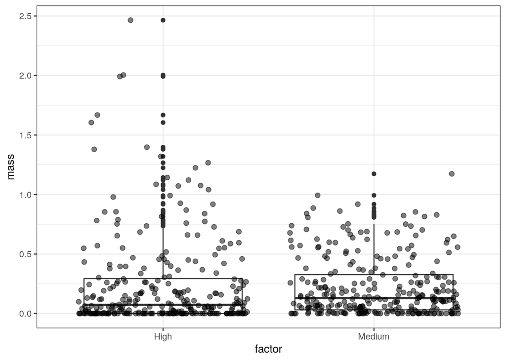

```r
ggplot(med_high_data, aes(factor, mass))+
     geom_boxplot()+
     geom_point(position = "jitter", size = 2, alpha = 0.5)+
     theme_bw()
```

The plots look to be slightly different, but lets do a formal test.

Now let’s do a t-test

```r
MyT2<-t.test(mass ~ factor, data = med_high_data)
MyT2
```

```
##
##  Welch Two Sample t-test
##
## data:  mass by factor
## t = 0.72257, df = 476.95, p-value = 0.4703
## alternative hypothesis: true difference in means between group High and group Medium is not equal to 0
## 95 percent confidence interval:
##  -0.03401903  0.07359046
## sample estimates:
##   mean in group High mean in group Medium
##            0.2436893            0.2239036
```

We cannot reject the null hypothesis given that p > .05, so there is no clear difference between mass for medium and high factors.

## Now lets do low vs high factors

```r
low_high_data<-dry_mass %>% filter(factor == "Low" | factor == "High")

low_high_data$factor <- factor(low_high_data$factor)
```

Lets look at a figure of the data

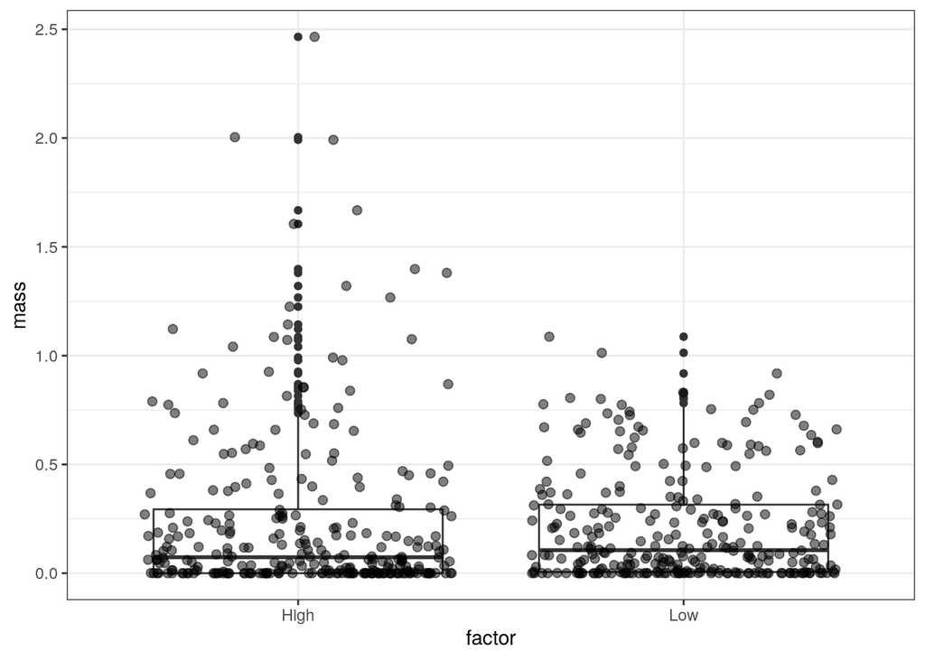

```r
ggplot(low_high_data, aes(factor, mass))+
     geom_boxplot()+
     geom_point(position = "jitter", size = 2, alpha = 0.5)+
     theme_bw()
```

The plots look similar, but lets do a formal test.

Now let’s do a t-test

```r
MyT<-t.test(mass ~ factor, data = low_high_data)
MyT
```

```
##
##  Welch Two Sample t-test
##
## data:  mass by factor
## t = 1.2517, df = 474.07, p-value = 0.2113
## alternative hypothesis: true difference in means between group High and group Low is not equal to 0
## 95 percent confidence interval:
##  -0.01947233  0.08781519
## sample estimates:
## mean in group High  mean in group Low
##          0.2436893          0.2095179
```

We cannot reject the null hypothesis given that p > .05, so there is no clear difference between mass for low and high factors. However, the p value was lowest for low vs high, so there is the highest level of difference between low and high factors when compared to high and med and low and med.